# Lab 8: Zagat Reviews

In this lab, we will continue our study of linear regression by fitting models with multiple predictors. **You will be submitting the Rmd and html files as usual. Be sure to show the code and output (without error messages or warnings) for all exercise code chunks.**

**Resources** Please consult the slidedecks on linear regression models from weeks 5 and 6 on the [Class Schedule](https://canvas.uw.edu/courses/1721011/pages/class-schedule) for help with the various functions on this lab.

## Introduction

No matter where you are or where you’ve been, there’s an excellent chance that you’ve been to an Italian restaurant before. The Italian restaurants in New York City are legendary, and it’s time to put your newly-developed regression modeling skills to work to understand how they operate.

What are the factors that contribute to a price of a meal at Italian restaurants in New York City? We will address this question with a series of multiple regression models.

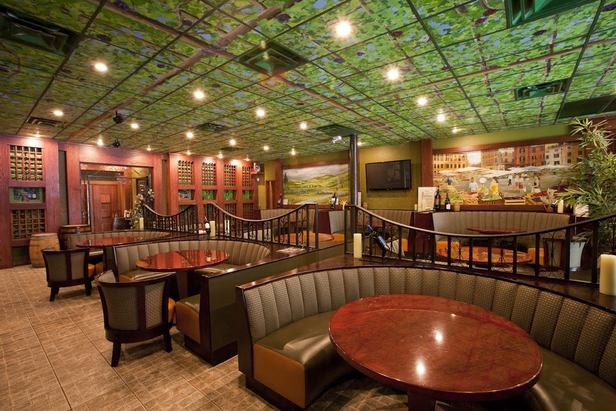

**Learning goals**

- Practice fitting models with multiple variables, making predictions and interpreting model results and performance.

## Getting Started

Launch the RStudio image on JupyterHub by clicking [here](https://jupyter.rttl.uw.edu/2024-spring-stat-311-a/user-redirect/rstudio).

Create a new lab report template to save your answers to the exercises. Be sure to personalize the header with the title of the lab and also add your name. You can also change the output type to `html_document` like you did on Lab 5 and customize the theme of your report to your liking.

### Packages

We will work with the **tidyverse** package and **tidymodel** packages as before. In addition, we will use the **skimr** package to get a quick summary of the data and the **GGally** package for making scatterplot matrices. Go ahead and add these packages to your document in the `load-packages` code chunk at the top of your Rmarkdown document.

You should also load the packages by running the following in the Console.

```r
library(tidyverse)           #umbrella suite
library(tidymodels)          #for model calculations
library(GGally)              #for scatterplot matrices
library(skimr)               #for quick summary/overview
```

### Data

Our data come in the form of Zagat reviews from 168 Italian restaurants in New York City from 2001. The Zagat guide is an influential review of restaurants. They are made famous by their use of selective quotes from actual diners to build a pithy description of each restaurant. But we won’t be working with the text. Rather, we will be working with the numeric reviews. Each restaurant is rated on a scale of 0 to 30 for the quality of its food, decor, and service. The average price of a meal—which includes one drink and a tip — will be our response variable.

Go ahead and read the data and save it in a dataframe called `nyc_italian`. The dataset is in a comma separated value (CSV) format and stored online.

Type the following code in the `load-packages` code chunk of your document. Then run the code to load the dataframe in your working Environment.

```r
nyc_italian <- read_csv(file="https://gattonweb.uky.edu/sheather/book/docs/datasets/nyc.csv")
```

The above code exemplifies the use of the `read_csv` function from the **tidyverse** suite, for reading in CSV data files. We have used it previously for reading in a CSV file stored on our computer.

Some non-programming (but extremely important) tasks to complete at this stage are:

- Take a look at your dataframe in the spreadsheet viewer. What does each row represent?
- Peek at the data using the `glimpse` function to see the variable types and what values they typically take on.
- **skim** the dataset for missing values and to calculate quick summaries. Type the following code in your Console. It should give you a summary of all the columns in your data except for the first two (which are merely identifiers). Are there any missing values?

```r
### type in Console
nyc_italian %>%
            select(-Case, -Restaurant) %>%
                    skim()
```

The `East` variable records whether the restaurant is located east or west of Fifth Avenue, which historically divides the island of Manhattan. Note that it has been entered as a numeric variable with values 0 and 1 instead of a character variable.

Let’s begin by recoding `East` into a character variable called `east` which takes the value “yes” for restaurants that are east of Fifth Avenue and “no” for restaurants that are west.

1. Create and add a new variable called `east` (**note the lowercase e**) to the `nyc_italian` dataframe which takes the value “yes” when the value of `East` is 1 and “no” when the value of `East` is 0. Then print the frequency distribution of the variable `east` you have just created.

### Creating the Training/Testing Split

Before we begin building models, let us first **randomly** split the dataset into two subsets:

- the **training** split will contain 80% of the data and we will use this for building our model.
- the **testing** split will contain the remaining 20% and we will use this for comparing the models we build on their predictive abilities.

Create a new code chunk called *data-splitting* with chunk option set to `include = FALSE` and type the following in it. See the footnote<sup>1</sup> for an explanation of this chunk option. Go ahead and run the code chunk as well so you can view the data subsets in your spreadsheet viewer.

```r
set.seed(1414)          #set random number seed

nyc_split <- initial_split(nyc_italian, prop = 0.8) #split data in two

nyc_train <- training(nyc_split) #training subset
nyc_test <- testing(nyc_split)   #testing subset
```

## Model building

In this section, we will build several models using the training data. Before we can sensibly build models, we should spend some time exploring the data. How are the variables distributed? How are they related to one another? What patterns are present?

The `ggpairs()` function can help us explore these relationships visually. It is particularly useful for numeric variables. It shows a grid of scatter plots for each pair of variables in the data frame. The syntax for `ggpairs()` is shown below. It is best to select the explanatory variables first ($x_1,x_2,x_3$ in the skeletal code shown below) and then the response variable $y$.

```r
dataframe %>%
             select( x1, x2, x3, y) %>%
              ggpairs(title =" ___ ")
```

2. Using the `nyc_train` dataset, make a scatterplot matrix of the response variable `Price` and the numeric ratings of `Food`, `Service` and `Decor`. Be sure to show your code and output. Also comment **briefly** on what you see. Specifically please just address in no more than three sentences:
   - overall relationship of the Price with Food, Decor and Service
   - the relationship between the ratings themselves.
3. Using `nyc_train`, make a boxplot to compare the `Price` by location (`east`). Also calculate and compare the mean price of a meal for restaurants east of Fifth Ave. with those west. Be sure to show your output and code without messages/warnings.

We will be using the `lm` function to fit several models to the `nyc_train` data, so let’s be careful to number the model functions. For each model, you will be saving the output from `lm` in an R object as indicated by the name of the model in the first column of the table below. Then using the `glance` function, you will calculate the adjusted $R^2$ to assess goodness of fit for that model. Recall that the adjusted $R^2$ tells us the percentage of variation in the response that is *explained* by the model. The larger this percentage, the better our model fits.

| Model number | Type of model | Explanatory variables in model |
| --- | --- | --- |
| `model1a` | simple | `Decor` |
| `model1b` | simple | `Food` |
| `model1c` | simple | `Service` |
| `model2` | main effects | `Decor`, `east` |
| `model3` | interaction effects | `Decor`, `east` |

As an example, the code below illustrates how you might fit `modelx` relating a response $y$ to an explanatory variable $x$, and save the numeric value of the adjusted $R^2$ from that model in a variable called `modelx_rsq`.

```r
modelx <- lm(y ~ x, data = <dataset name>)

modelx_rsq <- glance(modelx) %>%
                    select(adj.r.squared) %>% pull()
```

You can then report the adjusted $R^2$ for `modelx` within the text as a percentage (rounded to 2 decimal places) using inline code as shown in the graphic below.

[figure not shown]

You can also use the inline code to record the value of the adjusted $R^2$ for different models in a simple table as shown in the graphic below.

[figure not shown]

The output will look something like the following which makes for a nice, easy comparison.

| Model | Adjusted R square |
| --- | --- |
| `modelx` | 52.89% |
| `modelx1` | 61.43% |

4. Using `nyc_train`, fit the simple linear models: `model1a`, `model1b` and `model1c` for predicting `Price`. Calculate the adjusted $R^2$ for these models and report them in a table (rounded to 2 decimal places) as shown above. In a couple of sentences, state which model is best and relate your conclusion to your findings from Exercise 2 and why they make sense.

   Be sure to show your code and output for each model without messages or warnings and then the completed table.

We will now consider adding the categorical variable `east` as a predictor to our simple linear model. There are two ways to accomplish this, one is via a main effects model in which the influence of the explanatory variable on the response is unaffected by the other variables in the model. The other is an interaction effects model in which the influence of an explanatory variable on the response depends on the other variables in the model.

5. Using `nyc_train`, fit the main effects model - `model2` - and the interaction effects model - `model3` - predicting `Price` from `Decor` and `east` . Calculate the adjusted $R^2$ for these models and report them (rounded to 2 decimal places) in a small table.

   Be sure to show your code and output without messages or warnings and then the completed table.

**Caution** 🛑

Before proceeding to the next section, please make sure that you used the training dataset `nyc_train` for all the models that were fit in this section. If not, go back and re-do them.

## Model validation

Now that we have a few models under our belt, we will proceed to see how well they predict the `Price` for the restaurants in the testing dataset.

Recall that in order to examine how well a model predicts outcomes on the testing data, we can use the `augment` function from the **tidymodels** package. This function takes the output from `lm` and calculates predictions using the fitted model for a new dataset. It **augments** the dataset by adding two new columns called `.fitted` and `.resid` which contain the predicted value and prediction error for each observation.

As an example, the code below illustrates how you might use the `modelx` relating a response $y$ to an explanatory variable $x$, which was trained on dataset 1 to predict outcomes for testing dataset 2. We then calculate the accuracy of these predictions by calculating the **Root Mean Squared Error** (RMSE) which is the average difference between the predictions and the actual observed values (on a squared scale). The smaller the RMSE, the better the model is at predicting new outcomes.

Once again, the numeric value of the RMSE for a model can be saved as a numeric variable and included within text or in the cell of a table using inline code.

```r
#fit modelx on dataset 1 and save result to R object modelx

modelx <- lm(y ~ x, data = <dataset 1>)

#augment dataset 2 with predicted values and prediction
#errors using modelx and save augmented dataframe

modelx_pred <- augment(modelx, newdata  = <dataset 2> )

#calculate the RMSE of the predictions

modelx_rmse <- modelx_pred %>%
                 rmse(truth = y, estimate = .fitted) %>% pull()
```

The RMSE is not a percentage and you can just report it to 2 decimal places. For example, you may have output like the following.

| Model | Root mean square error (RMSE) |
| --- | --- |
| `model0` | 5.08 |

We will be evaluating the quality of the predictions from the following three models in the next exercise. All three had adjusted $R^2$ of a similar magnitude and deserve to move on to the next stage for further comparisons.

| Model number | Type of model | Explanatory variables in model |
| --- | --- | --- |
| `model1a` | simple | `Decor` |
| `model2` | main effects | `Decor`, `east` |
| `model3` | interaction effects | `Decor`, `east` |

6. Using `nyc_test`, calculate the root mean squared errors of prediction (RMSE) for the models `model1a`, `model2` and `model3` and also report the numbers in a table (rounded to 2 decimal places). Be sure to show your code and output for each model and then the table.

## Analysis

In this final section, we will fit `model2` which includes a main effect for `Decor` and `east` to the entire dataset. Based on our work in the previous sections, it has a very respectable adjusted $R^2$ for the training dataset. Additionally, it has a respectable RMSE for the testing data.

7. Using the entire dataset `nyc_italian`, fit a main effects model - call it `model_final` - predicting `Price` from `Decor` and `east`. Print the coefficients of the model in a tidy format and then give the equations of the two fitted lines, one for restaurants which are `east` of 5th avenue and those which are west.

   Be sure to show your code and output without messages or warnings.
8. Interpret the equations from the previous exercise to communicate the influence of the `Decor` zagat rating on the `Price` of a meal. Also, according to our model, how much more does a patron need to pay for meal at a restaurant which is located east of 5th Avenue.
9. Fill in the blanks in the code below to make a scatter plot of `Price` vs `Decor` with the points colored by `east` and overlay the fitted lines from the main effects model from exercise 7.

   ```r
   ggplot(data = ___,
      mapping = aes(x = ___,
                    y = ___,
                    color = ___) )+
   geom_point()+
   geom_abline( slope = ___,
              intercept = ___,
              color = "turquoise")+   #fitted line for restaurants east of 5th
   geom_abline( slope = ___,
              intercept = ___,
              color = "red")         #fitted line for restaurants west of 5th
   ```

## Wrap Up

Congratulations! This concludes Lab 8. Be sure to turn in your `.Rmd` and `.html` files by the due date.

This work is licensed under a [Creative Commons Attribution-ShareAlike 4.0 International License](http://creativecommons.org/licenses/by-sa/4.0/).

<sup>1. Note: the `include = FALSE` chunk option is a concise way to set three options: `echo = FALSE, message = FALSE, warning = FALSE`. Code chunks with this option set will run when the document is knit, however, neither the code nor the output from running it will be displayed in the report. This is handy for code chunks where we load packages, do data pre-processing and other humdrum tasks.</sup>